# Final Bootstrap Analysis

Steve Pederson

18 February 2016

# Load packages & Data

## Packages

If you don’t have the packages `funsForLu` or `spShortcuts` installed, these can be installed using `library(devtools)` then `install_github("steveped/funsForLu")` and `install_github("steveped/spShortcuts")`

```r
library(ggplot2)
library(stringr)
library(reshape2)
library(matrixStats)
library(VennDiagram)
library(knitr)
library(xtable)
library(corrplot)
library(scales)
library(pscl)
library(boot)
library(lmtest)
library(dplyr)
library(parallel)
library(funsForLu)
library(spShortcuts)
library(magrittr)
```

## Data Setup

```r
tpmFile <- file.path("data", "Dec_log2_gene_expression_dataset.txt")
tpmData <- read.delim(tpmFile, sep="\t", stringsAsFactors = FALSE) %>%
  dplyr::select(ID, length, contains("TPM"), contains("IDs")) %>%
  tbl_df
```

This contains read counts as TPM values for 18777 RefSeq IDs. These were chosen as the longest canonical transcript for each gene.

```r
elements <- grep("IDs", colnames(tpmData), value = TRUE) %>%
  str_split_fixed(pattern="_", 3) %>%
  as.data.frame(stringsAsFactors = FALSE) %>%
  dplyr::select(type = V1, region = V2) %>%
  lapply(unique) %>%
  lapply(sort)
```

The list of possible element types and regions was then created, with 5 element types under consideration across 4 genomic regions. Logical variables for each element type and region were then added to the main `tpmData` object.

```r
tpmData %<>%
  bind_cols(
    sapply(elements %>% unlist %>% as.vector,
           function(x){
             dplyr::select(tpmData, contains(x)) %>%
               rowSums %>%
               as.logical
             },
           simplify = FALSE) %>%
  as.data.frame() )
```

The complete set of tissues was also defined as a character vector.

```r
tissues <- gsub("_TPM", "", grep("TPM", colnames(tpmData), value = TRUE))
```

# Data Inspection

## Inspection By Element Type

Counts of each element type & their co-occurence were then obtained and plotted as a Venn Diagram

```r
typeVenn <- tpmData %>%
  dplyr::select(one_of(elements$type)) %>%
  getVennCounts
```

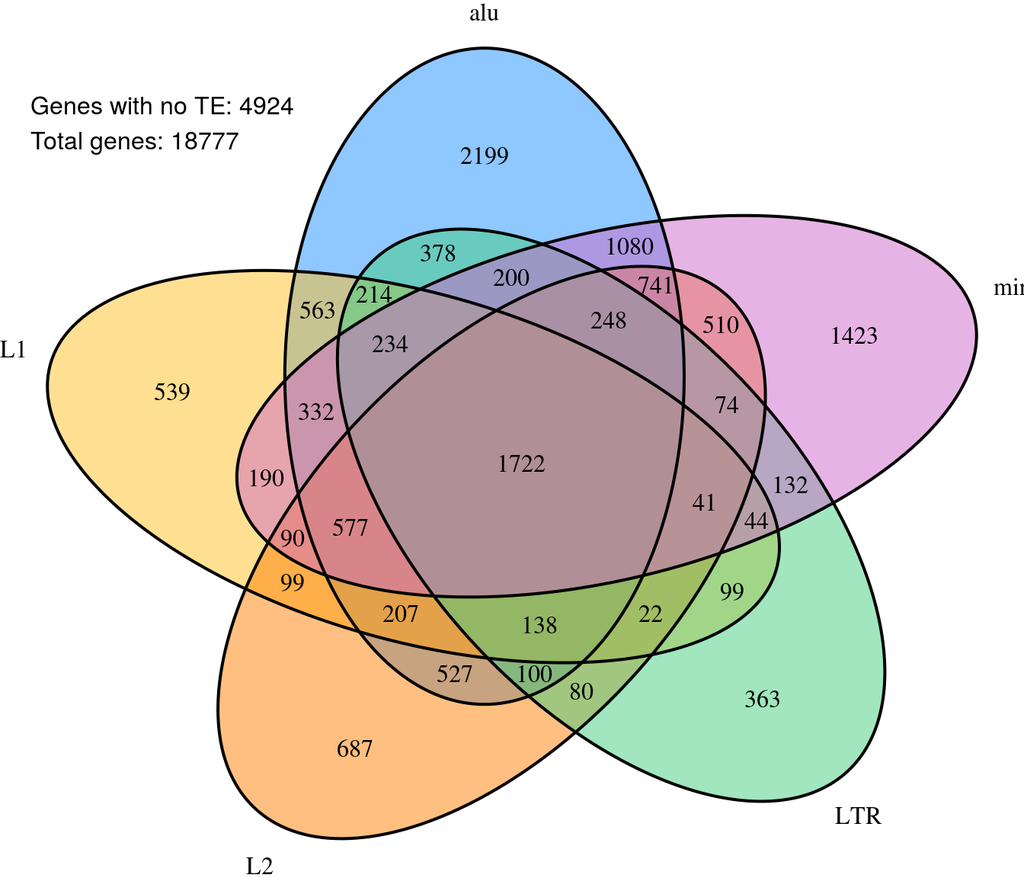

This plot revealed that the majority of TEs occur in genes with other TEs.

```r
singleElements <- lapply(seq_along(elements$type),
                         function(x){
                           filter_(tpmData,
                                   elements$type[x],
                                   paste(paste0("!", elements$type[-x]),
                                         collapse = " & "))["ID"]
                           }) %>%
  set_names(elements$type)
```

| Element Type | Total | Found In Isolation | Proportion |
| --- | --- | --- | --- |
| alu | 9460 | 2199 | 0.2324524 |
| L1 | 5111 | 539 | 0.1054588 |
| L2 | 5863 | 687 | 0.1171755 |
| LTR | 4089 | 363 | 0.0887748 |
| mir | 7638 | 1423 | 0.1863053 |

## Inspection By Genomic Region

This pattern was less pronounced when looking at TEs by genomic region

```r
regionVenn <- tpmData %>%
  dplyr::select(one_of(elements$region)) %>%
  getVennCounts
```

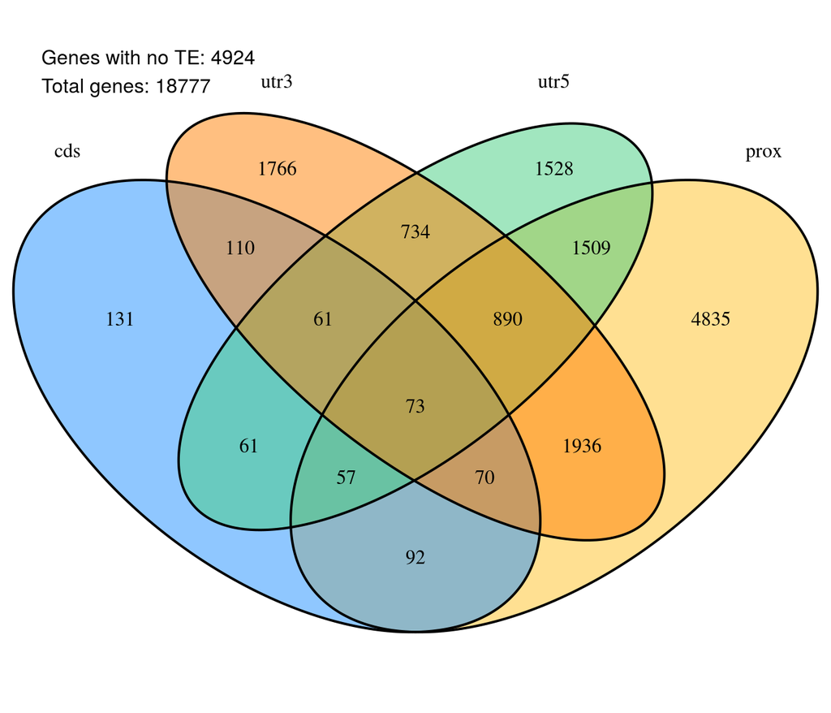

```r
singleRegion <- lapply(seq_along(elements$region),
                       function(x){
                         filter_(tpmData,
                                 elements$region[x],
                                 paste(paste0("!", elements$region[-x]),
                                       collapse = " & "))["ID"]
                         }) %>%
  set_names(elements$region)
```

| Region | Total | Element In One Region Only | Proportion |
| --- | --- | --- | --- |
| cds | 655 | 131 | 0.2000000 |
| prox | 9462 | 4835 | 0.5109913 |
| utr3 | 5640 | 1766 | 0.3131206 |
| utr5 | 4913 | 1528 | 0.3110116 |

# Analytic Approach

- Gene sets with the presence of a specific TE in a specific regions will be compared to gene sets without the TE. Whilst the genes in the first set will be selected using uniform probabilities, genes in the second set will be selected with probabilities such the the structure of the co-occurring elements should match that of the first set.
- Gene length will be set as an additional binning parameter to ensure that any bias in the TPM values due to gene length is also accounted for. 5 bins were used.
- Genes with all 5 elements will be excluded from the analysis
- 5 elements will be bootstrapped across 4 regions and 6, giving a total of 120 comparisons. All Confidence intervals will be adjusted to control the FWER taking these multiple comparisons into account.

```r
nComp <- length(elements$type)*length(elements$region)*length(tissues)
alpha <- 0.05/nComp
```

```r
nBins <- 5
nBoot <- 10000L
tpmData %<>% mutate(lengthBin = findInterval(length,
                                             quantile(length,
                                                      probs = seq(0, 1, length.out = nBins + 1)),
                                             rightmost.closed=TRUE))
confInt <- list()
```

# Bootstrap Analysis

## Alu Elements

### 3’UTR

```r
aluUtr3Data <- tpmData %>%
  mutate(
    elBins = dplyr::select(
      tpmData,
      one_of(grep("alu", elements$type, invert = TRUE, value = TRUE))
    ) %>%
    binsFromCols,
    elBins = paste(elBins, lengthBin, sep = "_")) %>%
  filter(!grepl("_.+_.+_.+_", elBins),
         alu_cds_IDs == 0,
         alu_prox_IDs == 0,
         alu_utr5_IDs == 0)
bootAluUtr3 <- mclapply(tissues,
                        bootMeans,
                        data = aluUtr3Data,
                        testIds = filter(aluUtr3Data, alu)$ID,
                        refIds = filter(aluUtr3Data, !alu)$ID,
                        binCol = "elBins",
                        nBoot = nBoot,
                        nGenes = 1000L,
                        maxP = 0.01)
names(bootAluUtr3) <- tissues
```

```r
confInt$aluUtr3 <- bootAluUtr3 %>%
  lapply(extract2, "samples") %>%
  lapply(quantile, probs = c(alpha/2, 0.5, 1 - alpha/2)) %>%
  lapply(t) %>%
  lapply(as.data.frame) %>%
  bind_rows() %>%
  set_names(c("lower", "median", "upper")) %>%
  mutate(Element = "Alu",
         Tissue = capwords(tissues, sep = "_"),
         Region = "3'UTR")
```

### 5’UTR

```r
aluUtr5Data <- tpmData %>%
  mutate(
    elBins = dplyr::select(
      tpmData,
      one_of(grep("alu", elements$type, invert = TRUE, value = TRUE))
    ) %>%
    binsFromCols,
    elBins = paste(elBins, lengthBin, sep = "_")) %>%
  filter(!grepl("_.+_.+_.+_", elBins),
         alu_cds_IDs == 0,
         alu_utr3_IDs == 0,
         alu_prox_IDs == 0)
bootAluUtr5 <- mclapply(tissues,
                        bootMeans,
                        data = aluUtr5Data,
                        testIds = filter(aluUtr5Data, alu)$ID,
                        refIds = filter(aluUtr5Data, !alu)$ID,
                        binCol = "elBins",
                        nBoot = nBoot,
                        nGenes = 1000L,
                        maxP = 0.01)
names(bootAluUtr5) <- tissues
```

```r
confInt$aluUtr5 <- bootAluUtr5 %>%
  lapply(extract2, "samples") %>%
  lapply(quantile, probs = c(alpha/2, 0.5, 1 - alpha/2)) %>%
  lapply(t) %>%
  lapply(as.data.frame) %>%
  bind_rows() %>%
  set_names(c("lower", "median", "upper")) %>%
  mutate(Element = "Alu",
         Tissue = capwords(tissues, sep = "_"),
         Region = "5'UTR")
```

### Proximal Promoters

```r
aluProxData <- tpmData %>%
  mutate(
    elBins = dplyr::select(
      tpmData,
      one_of(grep("alu", elements$type, invert = TRUE, value = TRUE))
    ) %>%
    binsFromCols,
    elBins = paste(elBins, lengthBin, sep = "_")) %>%
  filter(!grepl("_.+_.+_.+_", elBins),
         alu_cds_IDs == 0,
         alu_utr3_IDs == 0,
         alu_utr5_IDs == 0)
bootAluProx <- mclapply(tissues,
                        bootMeans,
                        data = aluProxData,
                        testIds = filter(aluProxData, alu)$ID,
                        refIds = filter(aluProxData, !alu)$ID,
                        binCol = "elBins",
                        nBoot = nBoot,
                        nGenes = 1000L,
                        maxP = 0.01)
names(bootAluProx) <- tissues
```

```r
confInt$aluProx <- bootAluProx %>%
  lapply(extract2, "samples") %>%
  lapply(quantile, probs = c(alpha/2, 0.5, 1 - alpha/2)) %>%
  lapply(t) %>%
  lapply(as.data.frame) %>%
  bind_rows() %>%
  set_names(c("lower", "median", "upper")) %>%
  mutate(Element = "Alu",
         Tissue = capwords(tissues, sep = "_"),
         Region = "Proximal Promoter")
```

### CDS Regions

```r
aluCdsData <- tpmData %>%
  mutate(
    elBins = dplyr::select(
      tpmData,
      one_of(grep("alu", elements$type, invert = TRUE, value = TRUE))
    ) %>%
    binsFromCols,
    elBins = paste(elBins, lengthBin, sep = "_")) %>%
  filter(!grepl("_.+_.+_.+_", elBins),
         alu_prox_IDs == 0,
         alu_utr3_IDs == 0,
         alu_utr5_IDs == 0)
bootAluCds <- mclapply(tissues,
                        bootMeans,
                        data = aluCdsData,
                        testIds = filter(aluCdsData, alu)$ID,
                        refIds = filter(aluCdsData, !alu)$ID,
                        binCol = "elBins",
                        nBoot = nBoot,
                        nGenes = 45,
                        maxP = 0.01)
names(bootAluCds) <- tissues
```

```r
confInt$aluCds <- bootAluCds %>%
  lapply(extract2, "samples") %>%
  lapply(quantile, probs = c(alpha/2, 0.5, 1 - alpha/2)) %>%
  lapply(t) %>%
  lapply(as.data.frame) %>%
  bind_rows() %>%
  set_names(c("lower", "median", "upper")) %>%
  mutate(Element = "Alu",
         Tissue = capwords(tissues, sep = "_"),
         Region = "CDS Regions")
```

## Summary for Alu Elements

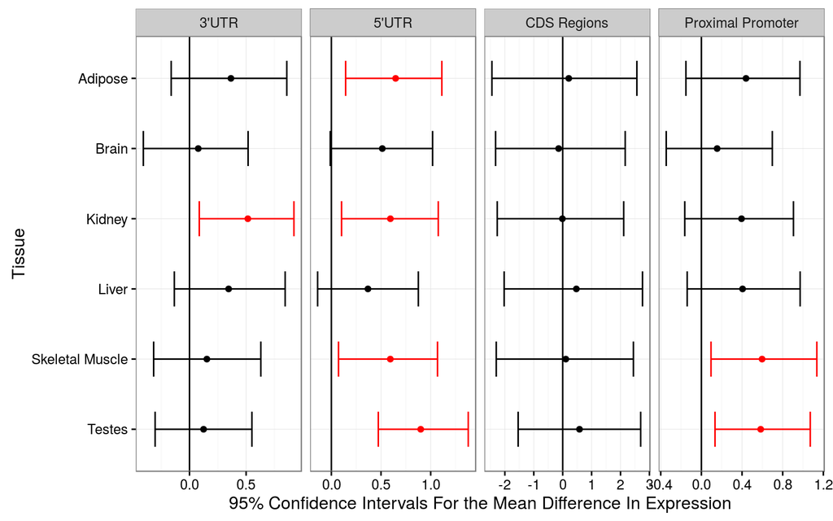

```r
confInt %>%
  bind_rows %>%
  mutate(Tissue = factor(Tissue, rev(sort(unique(Tissue)))),
         Sig  = sign(lower) == sign(upper)) %>%
  ggplot(aes(x = median, y = Tissue, colour = Sig)) +
  geom_point() +
  scale_color_manual(values = c("black", "red")) +
  geom_errorbarh(aes(xmin = lower, xmax = upper), height = 0.5) +
  facet_wrap(~Region, nrow=1, scales = "free_x") +
  geom_vline(xintercept = 0) +
  guides(colour = FALSE) +
  labs(x = "95% Confidence Intervals For the Mean Difference In Expression") +
  theme_bw()
```